# LAB 46 (MD)

AnaGSanjuanM

2023-03-17

————————–LABORATORIO 46————————–

Hecho con gusto por Carla Carolina Pérez Hernández (UAEH)

v2

————Alumna: Ana Grisel Sanjuan Merida———————

LABORATORIO - Gráficos en R con ggplot2 para Ciencia de Datos

Grafica de lineas en R

Instalar paquete con los datos

install.packages(“gapminder”)

install.packages(“ggplot2”)

Cargar libreria ggplot2 y gapminder

```r
library(ggplot2)
library(gapminder)
```

Cargar datos a entorno

```r
data("gapminder")
```

Filtrando ESPAÑA

Objeto llamado gapminderES

Proviene de gapminder

El country solo será España

El objeto generado está en el entorno de variables (environment)

Se visualiza al dar clic sobre el objeto

```r
gapminderES = gapminder[gapminder$country == "Spain" ,]
```

Para ver el transcurso del tiempo en una variable en cuestión

De ggplt se utilizan los datos recien generados

Graficando con un elemento estético

La variable X será igual a year

La viariable Y será igual a lifeExp

La gráfica será de líneas

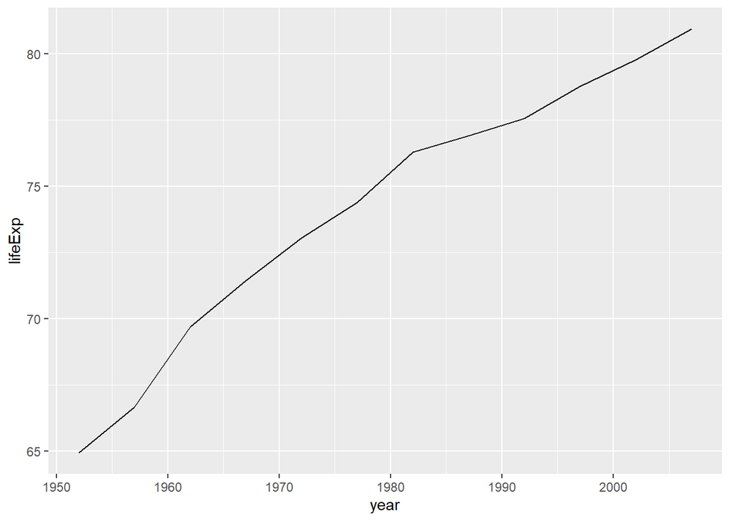

```r
ggplot (data = gapminderES,
        mapping = aes(x = year,
                      y = lifeExp)) +
  geom_line()
```

Modificando tipo de linea y color

Utilizando indicaciones anteriores

La línea será de tipo punteado y de color rojo

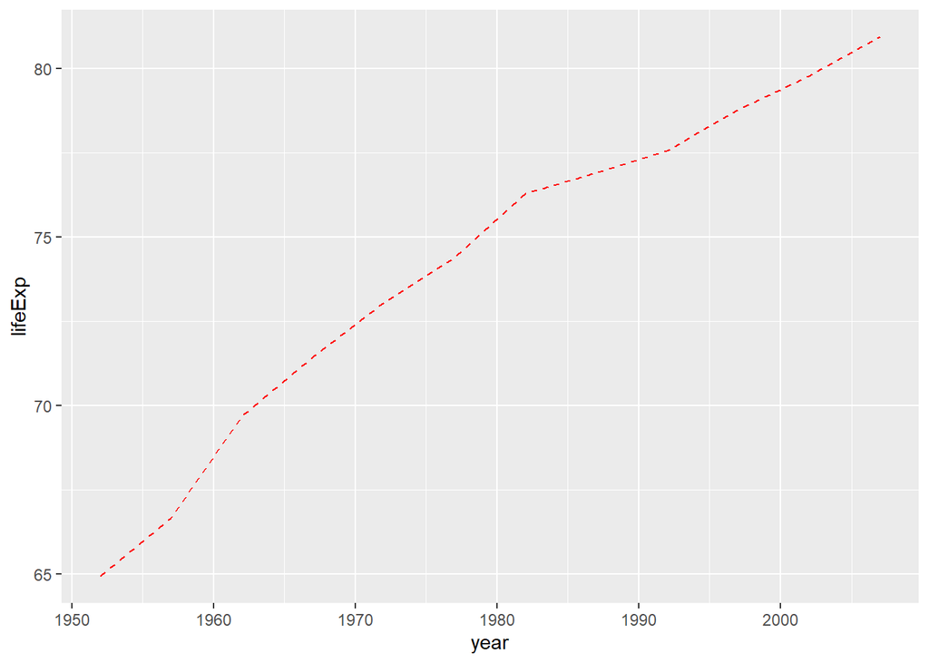

```r
ggplot (data = gapminderES,
        mapping = aes(x = year,
                      y = lifeExp)) +
  geom_line(linetype = "dashed",
            color = "red")
```

Modificando tamaño y hacer flecha

Utilizando indicaciones anteriores

Línea punteada rojo y agragando flecha tamaño 2

Se combinará con gráfico de puntos en tamaño 3

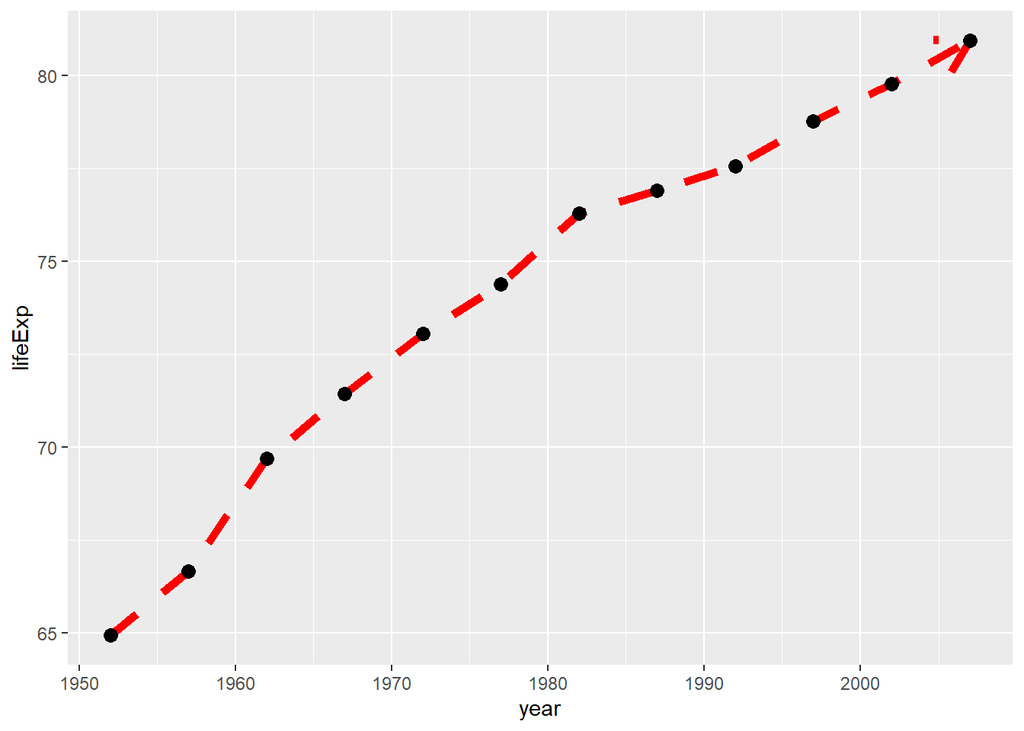

```r
ggplot (data = gapminderES,
        mapping = aes(x = year,
                      y = lifeExp)) +
  geom_line(linetype = "dashed",
            color = "red",
            arrow = arrow(),
            size = 2) +
  geom_point(size = 3)
```

Agregando puntos

Considerando los países de habla hispana

Se genera vector llamado hispam_vec

Se visualiza en el environment

```r
hispam_vec = c(
  'Argentina', 'Brazil', 'Bolivia', 'Chile', 'Colombia',
  'Costa Rica', 'Cuba', 'Dominican Republic',
  'Ecuador', 'El Salvador', 'Guatemala', 'Honduras',
  'Mexico', 'Nicaragua', 'Panama', 'Paraguay',
  'Peru', 'Uruguay',
  'Spain', 'Puerto Rico',
  'Venezuela' )
```

Trabajando gapminder con paises de habla hispana (valores recien elegidos)

Crear un objeto df

Generar objeto llamado gapminder_hisp

Tomando los países del vector recien creado (con %in%)

En el environment es posible ver el objeto creado

```r
gapminder_hisp = gapminder[gapminder$country %in% hispam_vec,]
```

Probando diferentes aestetics

Se extrae de gapminder_hisp

Graficando con un elemento estético

La variable X será igual a year

La viariable Y será igual a lifeExp

Se colorean los diferentes países

La gráfica será de líneas

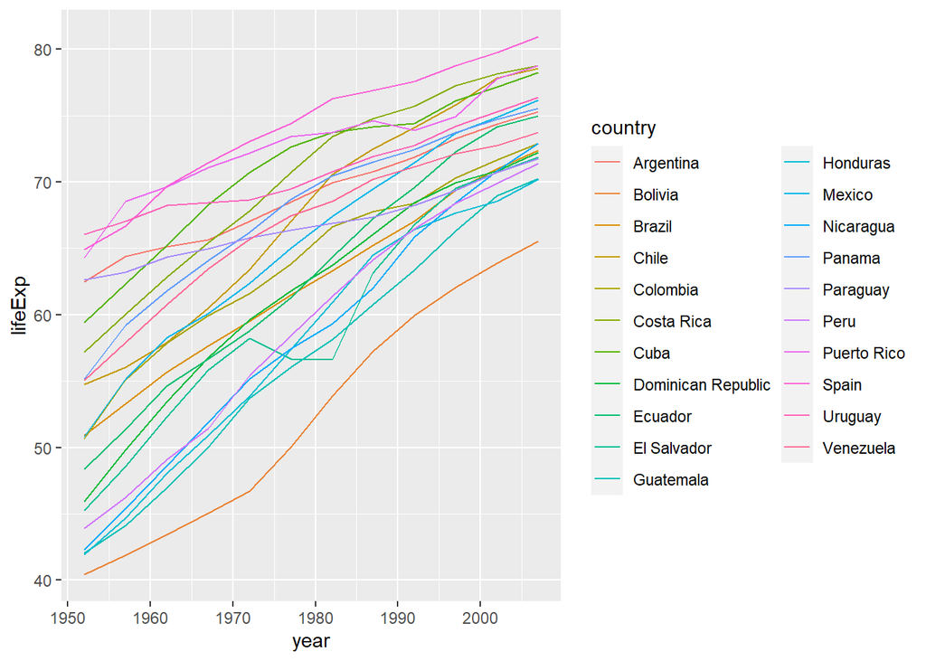

```r
ggplot (data = gapminder_hisp,
        mapping = aes(x = year,
                      y = lifeExp,
                      color = country)) +
  geom_line()
```

Exportar dataframe de los países hispano hablantes

```r
write.csv(gapminder_hisp, file="gapminder_hisp.csv")
```

————————-FIN DE LABORATORIO 46——————————